# Ocean Health Index Report

## Summary

The overall index score from the regional study (53) is slightly lower than that of the global study (62). [This link displays a table of **2014 global OHI scores** (for China), **China OHI+ scores** and the **differences between them**](http://htmlpreview.github.io/?https://github.com/OHI-Science/chn/blob/draft/province2015/reports/compare_scores_global_OHIplus.html), colors differences are colored from blue to red, with dark blue indicating the largest positive difference and red indicating the largest negative difference.

Regional assessment scores of CW, LSP, NP, and TR are higher than the global assessments. Reasons vary. CW and TR models are modified and different variables are incorporated. LSP and NP reference points are changed, which are easier to achieve than those in the global study.

Most goal scores are lower than their counterparts in the global study. AO has the most drastic reduction in score. This is due to the change in goal model. (Need to edit: The structure of the goal model automatically produces low scores, and needs to be revisited.) Model and/or data are changed for the other goals to suit local conditions and incorporate local data, which resulted in the decrease in score.

**Major Improvements**

- LSP’s reference point is changed to 5% protection, which is a management goal set by Chinese marine resource management and protection agencies to achieve by 2020.
- For MAR, we used coastal area permitted for mariculture as the area data, which produces a more realistic representation of mariculture status than using the entire coastal area for calculation.
- CS model included a new variable, relative carbon sequestration rate of each habitat. Together with habitat extent, these two variables provide a more complete picture of how habitats contribute to CS than extent alone could do.
- TR incorporated both international and local tourists data.

**Major areas for improvement**

Mostly we need higher quality, time-series data.

- Habitat data are scarce for some regions. Habitat trend was calculated based on available data. When there was only one year of data, the trend was assumed to be -0.1.
- Species area data was missing. SPP model wasn’t able to incorporate area data at all, reslting in an incomplete picture of the status of SPP and BD.
- AO model needs to be revisited. (Need to edit: Current model is not good)
- FIS catch data collection needs to be standardized and at finer scale. See the Goal Model Comparison table below for more detail.

## Results

### Results Table

|  | Score | Status | Future |
| --- | --- | --- | --- |
| Index | 52.6 |  | 51.65 |
| Food Provision | 33 | 31.79 | 34.22 |
| . Fisheries | 13.85 | 13.36 | 14.34 |
| . Mariculture | 51.93 | 49.76 | 54.1 |
| Artisanal Fishing Opportunity | 17.65 | 26.45 | 8.84 |
| Natural Products | 90.91 | 88.54 | 93.27 |
| Carbon Storage | 39.62 | 40.33 | 38.91 |
| Coastal Protection | 37.24 | 37.82 | 36.67 |
| Tourism &amp; Recreation | 81.95 | 77.21 | 86.69 |
| Coastal Livelihoods &amp; Economies | 58.39 | 44.2 | 72.58 |

[output cut: 9 more lines]

### Flower plot of country-level scores

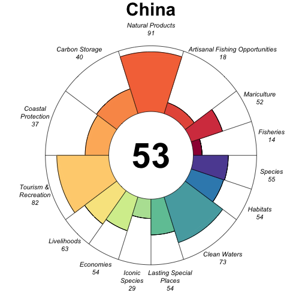

## Data

This section describes the percentage of data that is local. The rest of the data comes from the global assessment.

- 72.04 percent of all data was local.
- 100 percent of goal data was local.
- 80 percent of pressures data was local.
- 36.36 percent of resilience data was local.

## Goal model description and reference points

This table compares models and reference points from the OHI 2014 global assessment with the OHI+ China assessment. Note that while most global models are unchanged from the original 2012 assessment, some approches have been modified and are indicated in the table below.

| (Sub-)Goal | OHI 2014 global assessment | OHI+ China assessment |
| --- | --- | --- |
| **Fisheries** | Status model is based on B/B<sub>MSY</sub>, which is the estimated population biomass (B) relative to the biomass that can deliver maximum sustainable yield for each landed stock (B<sub>MSY</sub>). Re… | Status model and reference point are the same as in the global assessment 2012, which is based on multi-species MSY. China incorporated local, province-level harvest data to reveal finer differences a… |
| **Mariculture** | Status model is based on tonnes of harvest of mariculture species per coastal inhabitant (with coastal defined as within 25 km inland). The spatial reference point is the region with the highest value… | Status model and reference point are similar to the 2012 global assessment. The spatial reference point was the region with the highest value, but the status model was based on tonnes of mariculture s… |
| **Artisanal Fishing Opportunities** | Status model is based on the demand for artisanal fishing, estimated using indirect measures of poverty measured by the gross domestic product (GDP) per capita. Supply was estimated using an indicator… | Status model is rewritten and is similar to the 2014 U.S. West Coast assessment. It is based on the three indicators: - capcacity for exports, measured by the number of ports - the need for artisanal … |
| **Natural products** | Status model is based on the most recent harvest of each product per region relative to a fraction of the maximum value ever achieved in that region, with the assumption that the previous maximum achi… | Status model is the same as in global assessments, but the reference point was the 5-year production average due to large disparities in production among provinces. Three natural products were assesse… |
| **Coastal protection** | Status model is based on the amount and/or condition (depending on data availability) of marine habitat(s) and their ranked protective ability of each habitat type to protect the coast relative to the… | Status model is the same as in global assessments, and a temporal reference point for each habitat is set to its condition in 1980’s. Four habitats are measured: mangroves, seagrasses, salt marshes, a… |
| **Carbon storage** | Status model is based on the amount and/or condition (depending on data availability) of marine habitat(s) and their relative contribution to total carbon storage relative to their reference states in… | Our model improved upon the global model and included relative rate of carbon sequestration of each habitat to better reflect its carbon storage contribution. Mangroves, seagrasses, and saltmarshes we… |
| **Clean Waters** | Status model is based on categories of pollution: eutrophication/nutrients, chemicals, pathogens and marine debris. The reference point is that waters are free from all pollution. | Status model is similar to global assessments, and the same reference point that waters are free from all pollution. Pollution is based on nitrogen, phosphate, chemical oxygen demand, and petroleum po… |
| **Tourism and Recreation** | Status model is based on the proportion of direct employment in the tourism industry relative to total labor force as an indirect measure for the total number of people engaged in coastal tourism and … | Status model is based on the ratio of visitors and coastal area, and the spatial reference point was the region with the highest ratio across all years. The number of visitors included both domestic a… |
| **Livelihoods** | Status model is based on the number of direct and indirect jobs across marine sectors within a region and the average wages within each sector. Jobs has a moving target temporal reference point; the o… | Status model is the based on the number of direct jobs across marine sectors and the average disposable income among rural and urban inhabitants within a region. Both jobs and wages have a spatial ref… |
| **Economies** | Status model is based on the total revenue generated directly and indirectly from each marine sector. The reference point was a moving target temporal comparison, with a correction based on a region’s… | Status model is the same as in global assessments, and the spatial reference point is the maximum revenue across all years. Data on revenue generated from each marine sector is not available, and thus… |
| **Iconic Species** | Status model is based on the average extinction risk of identified iconic species, calculated as the weighted sum of the number of species in each threat category, where an increasing weight is assign… | Status model is similar to global assessment model. However, data is localized by including species listed in China’s List of Protected Species. The reference point is to have the risk status of all i… |
| **Lasting Special Places** | Status model is based on the percent of coastal waters that are special, measured by coastal marine protected areas and the percent of public or protected land along the coast. Both sea and land compo… | Status model is similar to global assessments, but the reference point is only 5% protection, a target set by national marine protection policies to achieve by 2020. Additionally, only coastal marine … |
| **Habitats** | Status model is based on the amount and/or condition (depending on data availability) of marine habitat(s) relative to their reference states in the early 1980’s. | Status model is the same as in global assessments, and a temporal reference point for each habitat is set to its condition in 1980’s. Three types of habitats were assessed: seagrasses, saltmarsh, and … |
| **Species** | Status model is based on the average extinction risk of all assessed species, calculated as the weighted sum of area and the number of species in each threat category, where an increasing weight is as… | Status model is similar to global assessments. However, average extinction risk of all assessed species was only calculated as the weighted sum of the number of species in each threat category, since … |